# 590_Project

```r
#Coefficient of correlation for CA/CAo vs Time (model=m3)#
Rsquared_CAO <- cor(CAM$CAO, predict(m3))

#generate table for regression parameters#
reg3<- tidy(m3)

e <- reg3$estimate
e <- e[c(1)]

f <- reg3$estimate
f <- f[c(2)]

#regression for CA using next method#
m4 <- nls(CAT~h*(Time^g)+1,start=list(h=1,g=1), data=CAM)
m4
```

```
## Nonlinear regression model
##   model: CAT ~ h * (Time^g) + 1
##    data: CAM
##       h       g
## 0.04518 0.31201
##  residual sum-of-squares: 0.002437
##
## Number of iterations to convergence: 9
## Achieved convergence tolerance: 1.956e-06
```

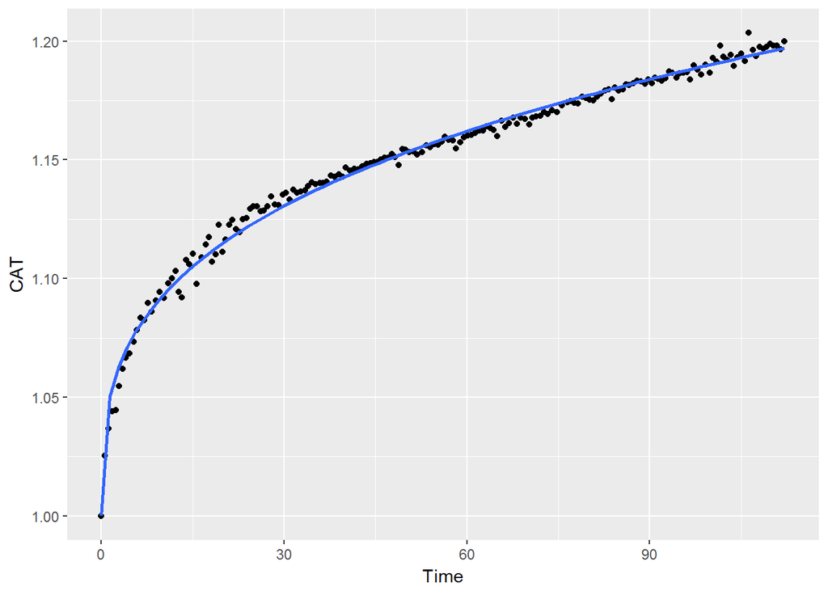

```r
CATplot <- ggplot(data=CAM, aes(x=Time, y=CAT))+
  geom_point()+
  geom_smooth(method="nls",
              formula=y~1+(h*(x^g)),
              method.args=list(start=c(h=1, g=1)),
              se=FALSE)
print(CATplot)
```

```r
Rsquared_CAT <- cor(CAM$CAT, predict(m4))

#generate table or regression parameters#
reg4 <- tidy(m4)

h <- reg4$estimate
h <- h[c(1)]

g <- reg4$estimate
g <- g[c(2)]

#Fit CAeq using the range from Diam vs Time regression and the model m4#
CATeq <- (Co)/(1+(h*(range^g)))

#Fit CAeq using the range from Diam vs Time regression and the model m3#
CAOeq <- (1+e*range^f)*(Co)

#Store the information for this rep in a data frame#
CM_S2_1B <- data.frame(range, b, e, f, g, h, Rsquared_Diam, Rsquared_CAO, Rsquared_CAT, CAOeq, CATeq)

#Pull the data from the desktop#
cadata <- readxl::read_excel("CM-S2-1C_FINAL.xlsx")
cadata <- data.frame(cadata)

#Select on the variables of CA, Time, and Diameter#
CAM <- data.frame(CA=c(cadata$Var.6), Time=c(cadata$Var.13), Diam=c(cadata$Var.11))

#Select only the values in the column which are numeric#
CAM <- CAM[!is.na(as.numeric(as.character(CAM$CA))), ]
#Transform the data back into numbers, extract CAo (Co)#
CA<-c(as.numeric(levels(CAM$CA))[CAM$CA])
Time<-c(as.numeric(levels(CAM$Time))[CAM$Time])
Diam<-c(as.numeric(levels(CAM$Diam))[CAM$Diam])
```

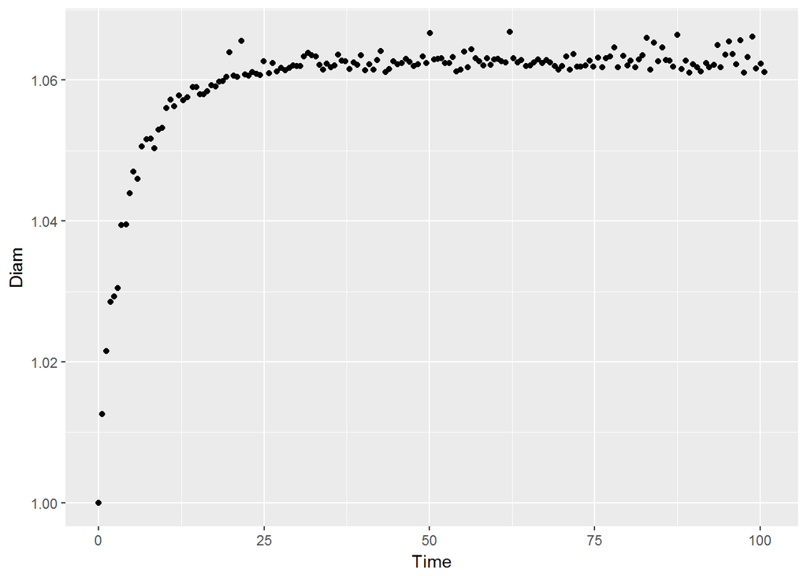

```r
Co<-CA[c(1)]
Do<-Diam[c(1)]

Diam <- c(Diam/Do)
CAT <- c(Co/CA)
CAO <- c(CA/Co)

CAM <- data.frame(CA=c(CA), Time=c(Time), Diam=c(Diam), CAO=c(CAO), CAT=c(CAT))

#Plot raw data Diameter vs Time#
library(ggplot2)
Diamplot <- ggplot(CAM, aes(Time, Diam))+
  geom_point()

print(Diamplot)
```

```r
#regression for Diam vs Time#
m <- nls(Diam ~ 1+b*(1-exp(-Time/a)),start=list(a=1,b=1), data=CAM)
m
```

```
## Nonlinear regression model
##   model: Diam ~ 1 + b * (1 - exp(-Time/a))
##    data: CAM
##      a      b
## 4.0819 0.0624
##  residual sum-of-squares: 0.0004606
##
## Number of iterations to convergence: 9
## Achieved convergence tolerance: 5.886e-06
```

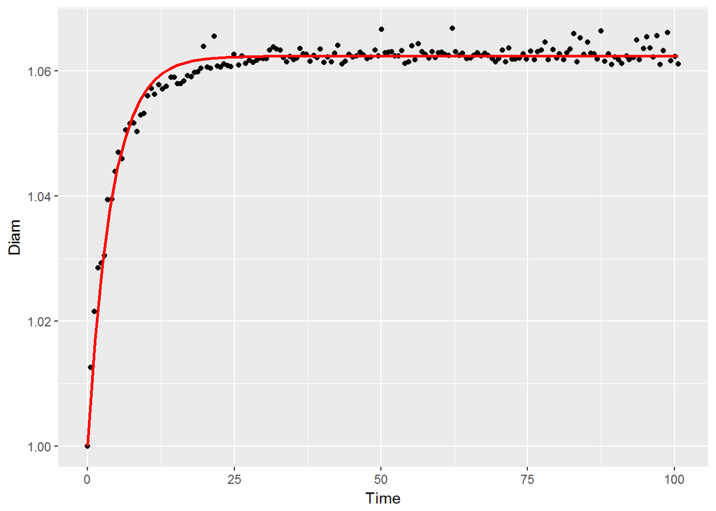

```r
#plot for Diam vs time#
Diamplot1<-ggplot(data=CAM, aes(x=Time,y=Diam))+
  geom_point()+
  geom_smooth(method="nls",
              formula=y~1+b*(1-exp(-x/a)),
              method.args=list(start=c(a=1, b=1)),
              se=FALSE,
              data=CAM,
              color="red")

print(Diamplot1)
```

```r
#Coefficient of Correlation for Diam vs Time model#
Rsquared_Diam <- cor(CAM$Diam, predict(m))

#generate table for regression parameters#
library(broom)
reg <- tidy(m)

#transform a parameter into range of regression#
a <- reg$estimate
a <- a[c(1)]
range <- 3*a

#make a variable for the b parameter for diameter vs time#
b <- reg$estimate
b <- b[c(2)]

#regression for CAO=(CA/Cao) vs Time#
m3 <- nls(CAO~1+e*(Time^f),start=list(e=1,f=1), data=CAM)
m3
```

```
## Nonlinear regression model
##   model: CAO ~ 1 + e * (Time^f)
##    data: CAM
##        e        f
## -0.02953  0.33824
##  residual sum-of-squares: 0.003668
##
## Number of iterations to convergence: 8
## Achieved convergence tolerance: 1.886e-06
```

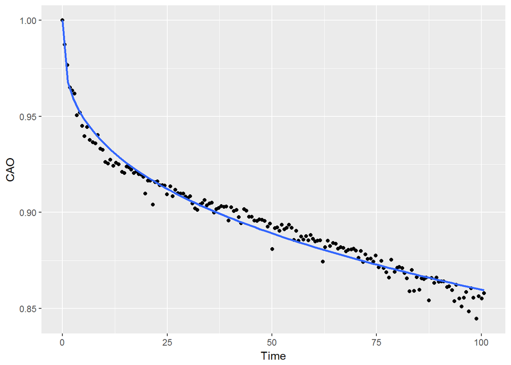

```r
#plot for m3#
CAOplot <- ggplot(data=CAM, aes(x=Time, y=CAO))+
  geom_point()+
  geom_smooth(method="nls",
              formula=y~1+(e*x^f),
              method.args=list(start=c(e=1, f=1)),
              se=FALSE)

print(CAOplot)
```

```r
#Coefficient of correlation for CA/CAo vs Time (model=m3)#
Rsquared_CAO <- cor(CAM$CAO, predict(m3))

#generate table for regression parameters#
reg3<- tidy(m3)

e <- reg3$estimate
e <- e[c(1)]

f <- reg3$estimate
f <- f[c(2)]

#regression for CA using next method#
m4 <- nls(CAT~h*(Time^g)+1,start=list(h=1,g=1), data=CAM)
m4
```

```
## Nonlinear regression model
##   model: CAT ~ h * (Time^g) + 1
##    data: CAM
##       h       g
## 0.02843 0.37880
##  residual sum-of-squares: 0.006243
##
## Number of iterations to convergence: 8
## Achieved convergence tolerance: 7.148e-06
```

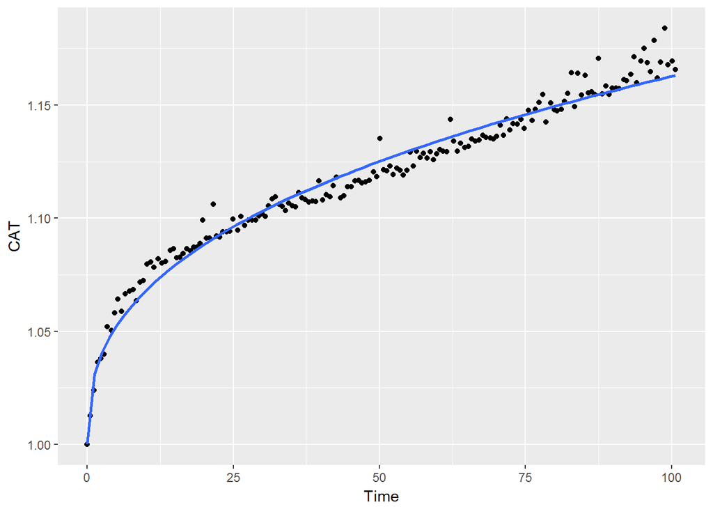

```r
CATplot <- ggplot(data=CAM, aes(x=Time, y=CAT))+
  geom_point()+
  geom_smooth(method="nls",
              formula=y~1+(h*(x^g)),
              method.args=list(start=c(h=1, g=1)),
              se=FALSE)
print(CATplot)
```

```r
Rsquared_CAT <- cor(CAM$CAT, predict(m4))

#generate table or regression parameters#
reg4 <- tidy(m4)

h <- reg4$estimate
h <- h[c(1)]

g <- reg4$estimate
g <- g[c(2)]

#Fit CAeq using the range from Diam vs Time regression and the model m4#
CATeq <- (Co)/(1+(h*(range^g)))

#Fit CAeq using the range from Diam vs Time regression and the model m3#
CAOeq <- (1+e*range^f)*(Co)

#Store the information for this rep in a data frame#
CM_S2_1C <- data.frame(range, b, e, f, g, h, Rsquared_Diam, Rsquared_CAO, Rsquared_CAT, CAOeq, CATeq)

#Pull the data from the desktop#
cadata <- readxl::read_excel("CM-S2-2A_FINAL.xlsx")
cadata <- data.frame(cadata)

#Select on the variables of CA, Time, and Diameter#
CAM <- data.frame(CA=c(cadata$Var.6), Time=c(cadata$Var.13), Diam=c(cadata$Var.11))

#Select only the values in the column which are numeric#
CAM <- CAM[!is.na(as.numeric(as.character(CAM$CA))), ]
#Transform the data back into numbers, extract CAo (Co)#
CA<-c(as.numeric(levels(CAM$CA))[CAM$CA])
Time<-c(as.numeric(levels(CAM$Time))[CAM$Time])
Diam<-c(as.numeric(levels(CAM$Diam))[CAM$Diam])
```

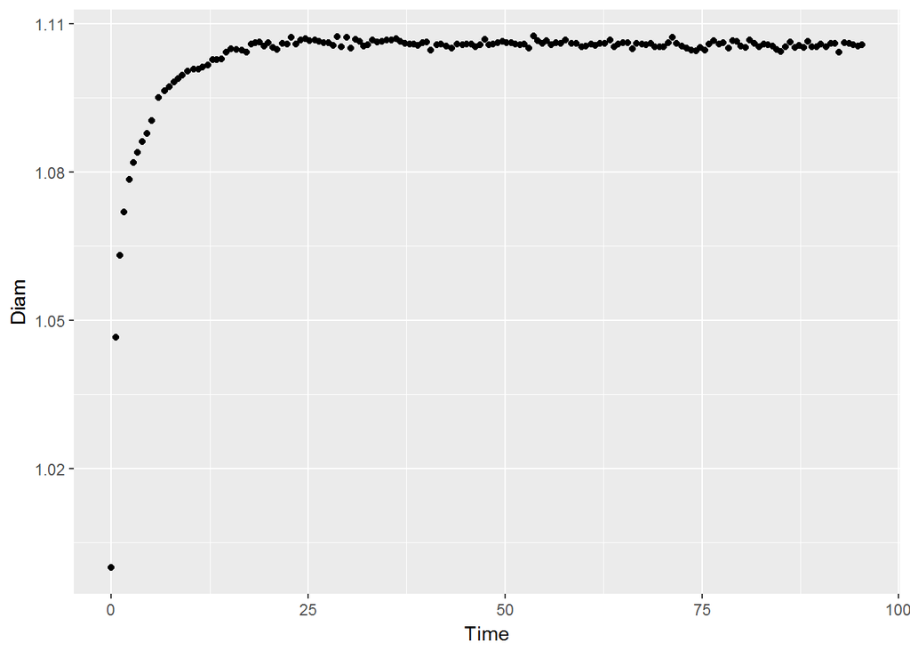

```r
Co<-CA[c(1)]
Do<-Diam[c(1)]

Diam <- c(Diam/Do)
CAT <- c(Co/CA)
CAO <- c(CA/Co)

CAM <- data.frame(CA=c(CA), Time=c(Time), Diam=c(Diam), CAO=c(CAO), CAT=c(CAT))

#Plot raw data Diameter vs Time#
library(ggplot2)
Diamplot <- ggplot(CAM, aes(Time, Diam))+
  geom_point()

print(Diamplot)
```

```r
#regression for Diam vs Time#
m <- nls(Diam ~ 1+b*(1-exp(-Time/a)),start=list(a=1,b=1), data=CAM)
m
```

```
## Nonlinear regression model
##   model: Diam ~ 1 + b * (1 - exp(-Time/a))
##    data: CAM
##      a      b
## 1.6689 0.1052
##  residual sum-of-squares: 0.001279
##
## Number of iterations to convergence: 12
## Achieved convergence tolerance: 3.986e-06
```

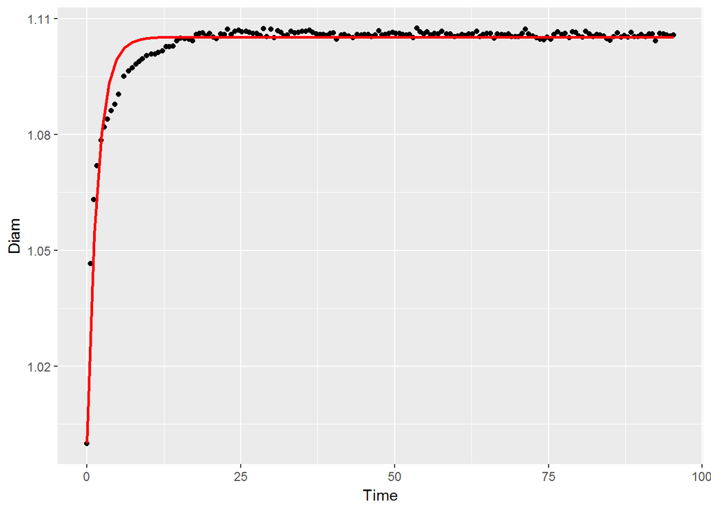

```r
#plot for Diam vs time#
Diamplot1<-ggplot(data=CAM, aes(x=Time,y=Diam))+
  geom_point()+
  geom_smooth(method="nls",
              formula=y~1+b*(1-exp(-x/a)),
              method.args=list(start=c(a=1, b=1)),
              se=FALSE,
              data=CAM,
              color="red")

print(Diamplot1)
```

```r
#Coefficient of Correlation for Diam vs Time model#
Rsquared_Diam <- cor(CAM$Diam, predict(m))

#generate table for regression parameters#
library(broom)
reg <- tidy(m)

#transform a parameter into range of regression#
a <- reg$estimate
a <- a[c(1)]
range <- 3*a

#make a variable for the b parameter for diameter vs time#
b <- reg$estimate
b <- b[c(2)]

#regression for CAO=(CA/Cao) vs Time#
m3 <- nls(CAO~1+e*(Time^f),start=list(e=1,f=1), data=CAM)
m3
```

```
## Nonlinear regression model
##   model: CAO ~ 1 + e * (Time^f)
##    data: CAM
##        e        f
## -0.07888  0.21633
##  residual sum-of-squares: 0.003322
##
## Number of iterations to convergence: 9
## Achieved convergence tolerance: 1.236e-06
```

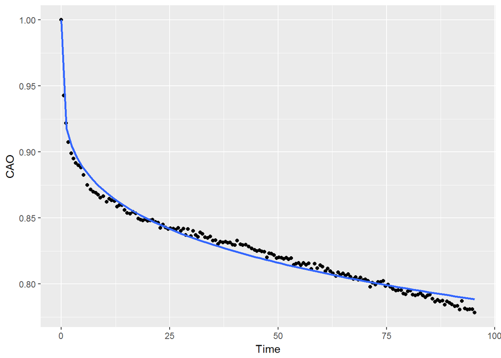

```r
#plot for m3#
CAOplot <- ggplot(data=CAM, aes(x=Time, y=CAO))+
  geom_point()+
  geom_smooth(method="nls",
              formula=y~1+(e*x^f),
              method.args=list(start=c(e=1, f=1)),
              se=FALSE)

print(CAOplot)
```

```r
#Coefficient of correlation for CA/CAo vs Time (model=m3)#
Rsquared_CAO <- cor(CAM$CAO, predict(m3))

#generate table for regression parameters#
reg3<- tidy(m3)

e <- reg3$estimate
e <- e[c(1)]

f <- reg3$estimate
f <- f[c(2)]

#regression for CA using next method#
m4 <- nls(CAT~h*(Time^g)+1,start=list(h=1,g=1), data=CAM)
m4
```

```
## Nonlinear regression model
##   model: CAT ~ h * (Time^g) + 1
##    data: CAM
##       h       g
## 0.08102 0.26215
##  residual sum-of-squares: 0.008316
##
## Number of iterations to convergence: 9
## Achieved convergence tolerance: 5.719e-07
```

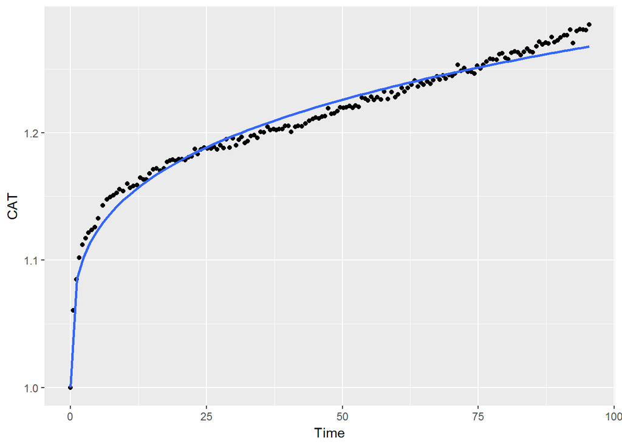

```r
CATplot <- ggplot(data=CAM, aes(x=Time, y=CAT))+
  geom_point()+
  geom_smooth(method="nls",
              formula=y~1+(h*(x^g)),
              method.args=list(start=c(h=1, g=1)),
              se=FALSE)
print(CATplot)
```

```r
Rsquared_CAT <- cor(CAM$CAT, predict(m4))

#generate table or regression parameters#
reg4 <- tidy(m4)

h <- reg4$estimate
h <- h[c(1)]

g <- reg4$estimate
g <- g[c(2)]

#Fit CAeq using the range from Diam vs Time regression and the model m4#
CATeq <- (Co)/(1+(h*(range^g)))

#Fit CAeq using the range from Diam vs Time regression and the model m3#
CAOeq <- (1+e*range^f)*(Co)

#Store the information for this rep in a data frame#
CM_S2_2A <- data.frame(range, b, e, f, g, h, Rsquared_Diam, Rsquared_CAO, Rsquared_CAT, CAOeq, CATeq)

#Pull the data from the desktop#
cadata <- readxl::read_excel("CM-S2-2B_FINAL.xlsx")
cadata <- data.frame(cadata)

#Select on the variables of CA, Time, and Diameter#
CAM <- data.frame(CA=c(cadata$Var.6), Time=c(cadata$Var.13), Diam=c(cadata$Var.11))

#Select only the values in the column which are numeric#
CAM <- CAM[!is.na(as.numeric(as.character(CAM$CA))), ]
#Transform the data back into numbers, extract CAo (Co)#
CA<-c(as.numeric(levels(CAM$CA))[CAM$CA])
Time<-c(as.numeric(levels(CAM$Time))[CAM$Time])
Diam<-c(as.numeric(levels(CAM$Diam))[CAM$Diam])
```

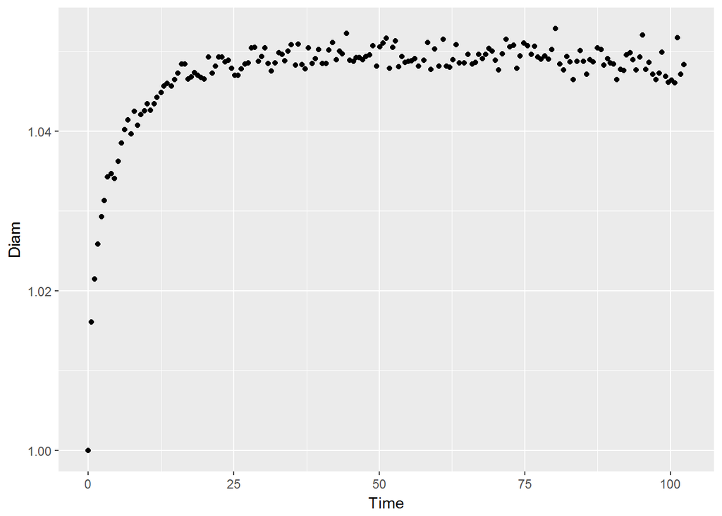

```r
Co<-CA[c(1)]
Do<-Diam[c(1)]

Diam <- c(Diam/Do)
CAT <- c(Co/CA)
CAO <- c(CA/Co)

CAM <- data.frame(CA=c(CA), Time=c(Time), Diam=c(Diam), CAO=c(CAO), CAT=c(CAT))

#Plot raw data Diameter vs Time#
library(ggplot2)
Diamplot <- ggplot(CAM, aes(Time, Diam))+
  geom_point()

print(Diamplot)
```

```r
#regression for Diam vs Time#
m <- nls(Diam ~ 1+b*(1-exp(-Time/a)),start=list(a=1,b=1), data=CAM)
m
```

```
## Nonlinear regression model
##   model: Diam ~ 1 + b * (1 - exp(-Time/a))
##    data: CAM
##       a       b
## 3.23785 0.04873
##  residual sum-of-squares: 0.0006574
##
## Number of iterations to convergence: 12
## Achieved convergence tolerance: 5.016e-06
```

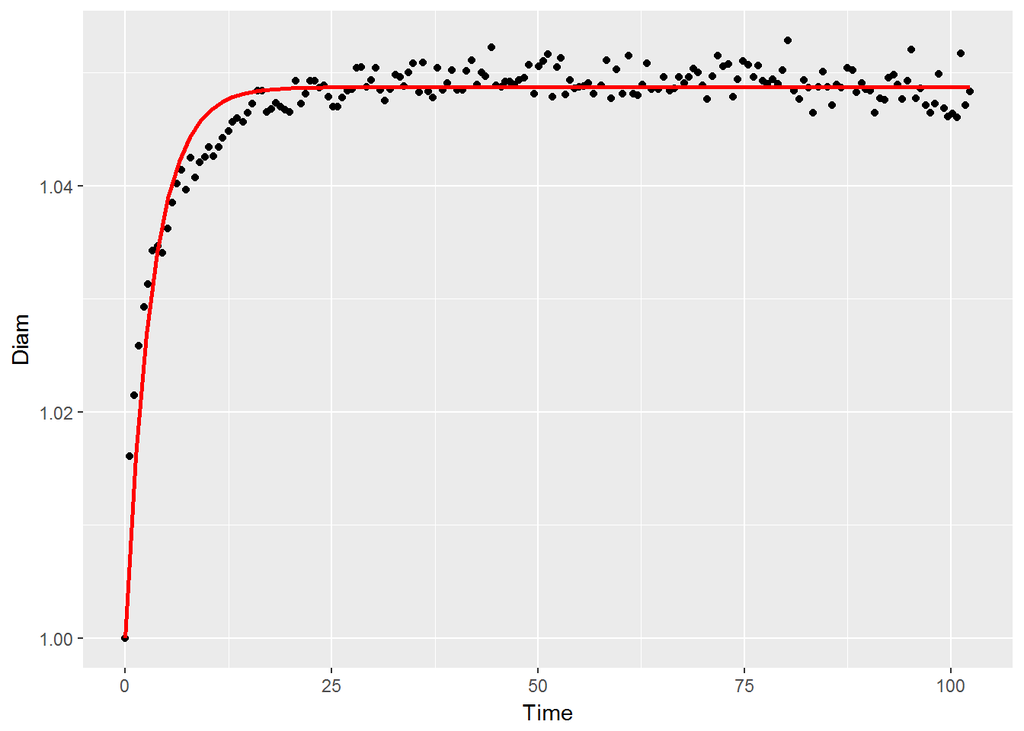

```r
#plot for Diam vs time#
Diamplot1<-ggplot(data=CAM, aes(x=Time,y=Diam))+
  geom_point()+
  geom_smooth(method="nls",
              formula=y~1+b*(1-exp(-x/a)),
              method.args=list(start=c(a=1, b=1)),
              se=FALSE,
              data=CAM,
              color="red")

print(Diamplot1)
```

```r
#Coefficient of Correlation for Diam vs Time model#
Rsquared_Diam <- cor(CAM$Diam, predict(m))

#generate table for regression parameters#
library(broom)
reg <- tidy(m)

#transform a parameter into range of regression#
a <- reg$estimate
a <- a[c(1)]
range <- 3*a

#make a variable for the b parameter for diameter vs time#
b <- reg$estimate
b <- b[c(2)]

#regression for CAO=(CA/Cao) vs Time#
m3 <- nls(CAO~1+e*(Time^f),start=list(e=1,f=1), data=CAM)
m3
```

```
## Nonlinear regression model
##   model: CAO ~ 1 + e * (Time^f)
##    data: CAM
##        e        f
## -0.02993  0.33639
##  residual sum-of-squares: 0.002528
##
## Number of iterations to convergence: 8
## Achieved convergence tolerance: 7.146e-06
```

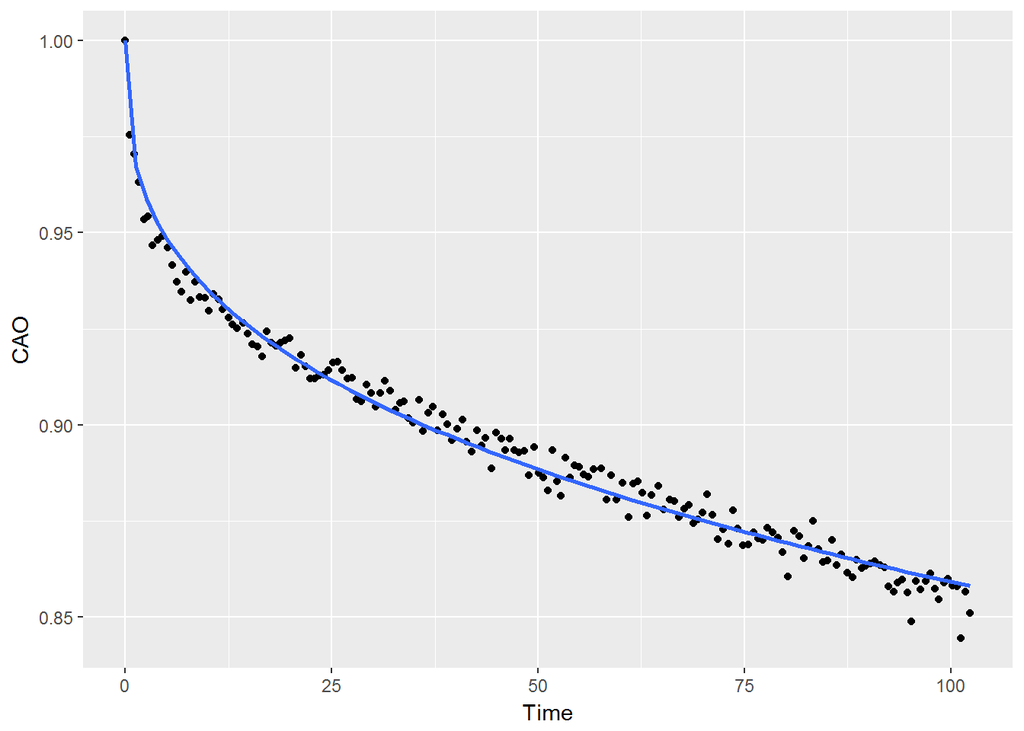

```r
#plot for m3#
CAOplot <- ggplot(data=CAM, aes(x=Time, y=CAO))+
  geom_point()+
  geom_smooth(method="nls",
              formula=y~1+(e*x^f),
              method.args=list(start=c(e=1, f=1)),
              se=FALSE)

print(CAOplot)
```

```r
#Coefficient of correlation for CA/CAo vs Time (model=m3)#
Rsquared_CAO <- cor(CAM$CAO, predict(m3))

#generate table for regression parameters#
reg3<- tidy(m3)

e <- reg3$estimate
e <- e[c(1)]

f <- reg3$estimate
f <- f[c(2)]

#regression for CA using next method#
m4 <- nls(CAT~h*(Time^g)+1,start=list(h=1,g=1), data=CAM)
m4
```

```
## Nonlinear regression model
##   model: CAT ~ h * (Time^g) + 1
##    data: CAM
##       h       g
## 0.02877 0.37756
##  residual sum-of-squares: 0.004488
##
## Number of iterations to convergence: 9
## Achieved convergence tolerance: 4.222e-07
```

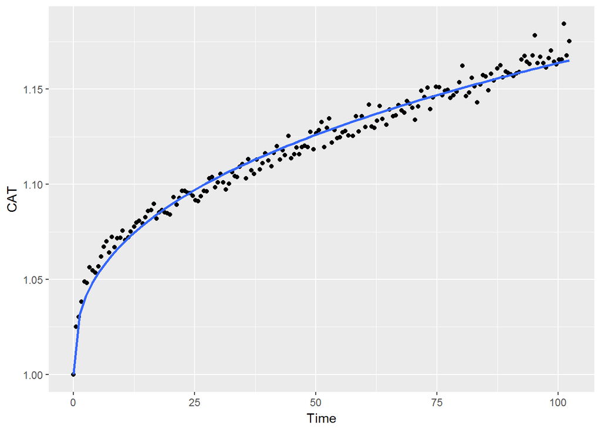

```r
CATplot <- ggplot(data=CAM, aes(x=Time, y=CAT))+
  geom_point()+
  geom_smooth(method="nls",
              formula=y~1+(h*(x^g)),
              method.args=list(start=c(h=1, g=1)),
              se=FALSE)
print(CATplot)
```

```r
Rsquared_CAT <- cor(CAM$CAT, predict(m4))

#generate table or regression parameters#
reg4 <- tidy(m4)

h <- reg4$estimate
h <- h[c(1)]

g <- reg4$estimate
g <- g[c(2)]

#Fit CAeq using the range from Diam vs Time regression and the model m4#
CATeq <- (Co)/(1+(h*(range^g)))

#Fit CAeq using the range from Diam vs Time regression and the model m3#
CAOeq <- (1+e*range^f)*(Co)

#Store the information for this rep in a data frame#
CM_S2_2B <- data.frame(range, b, e, f, g, h, Rsquared_Diam, Rsquared_CAO, Rsquared_CAT, CAOeq, CATeq)

#Pull the data from the desktop#
cadata <- readxl::read_excel("CM-S2-2C_FINAL.xlsx")
cadata <- data.frame(cadata)

#Select on the variables of CA, Time, and Diameter#
CAM <- data.frame(CA=c(cadata$Var.6), Time=c(cadata$Var.13), Diam=c(cadata$Var.11))

#Select only the values in the column which are numeric#
CAM <- CAM[!is.na(as.numeric(as.character(CAM$CA))), ]
#Transform the data back into numbers, extract CAo (Co)#
CA<-c(as.numeric(levels(CAM$CA))[CAM$CA])
Time<-c(as.numeric(levels(CAM$Time))[CAM$Time])
Diam<-c(as.numeric(levels(CAM$Diam))[CAM$Diam])
```

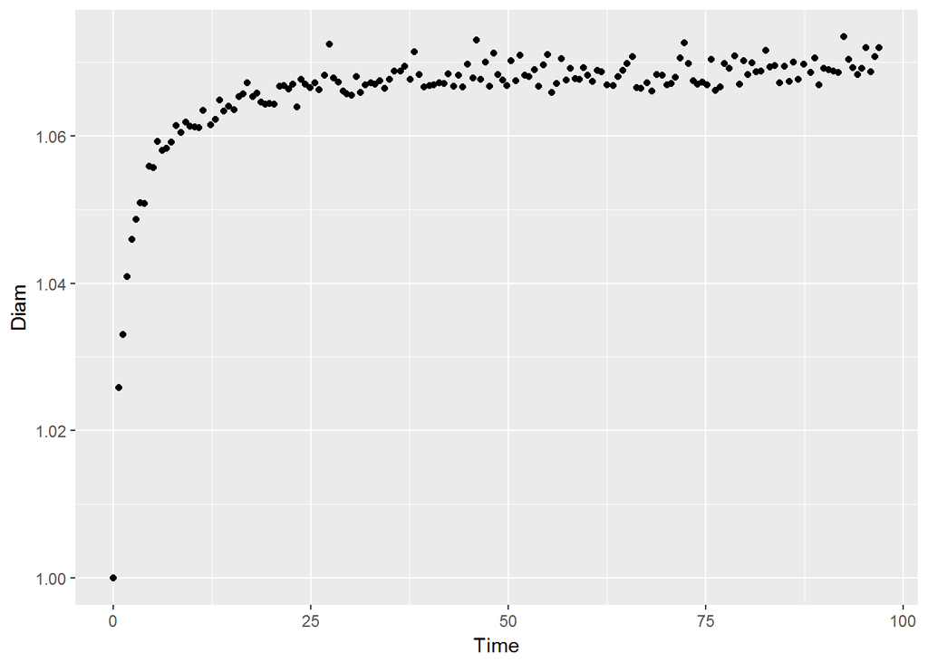

```r
Co<-CA[c(1)]
Do<-Diam[c(1)]

Diam <- c(Diam/Do)
CAT <- c(Co/CA)
CAO <- c(CA/Co)

CAM <- data.frame(CA=c(CA), Time=c(Time), Diam=c(Diam), CAO=c(CAO), CAT=c(CAT))

#Plot raw data Diameter vs Time#
library(ggplot2)
Diamplot <- ggplot(CAM, aes(Time, Diam))+
  geom_point()

print(Diamplot)
```

```r
#regression for Diam vs Time#
m <- nls(Diam ~ 1+b*(1-exp(-Time/a)),start=list(a=1,b=1), data=CAM)
m
```

```
## Nonlinear regression model
##   model: Diam ~ 1 + b * (1 - exp(-Time/a))
##    data: CAM
##       a       b
## 2.41652 0.06765
##  residual sum-of-squares: 0.001092
##
## Number of iterations to convergence: 11
## Achieved convergence tolerance: 9.903e-06
```

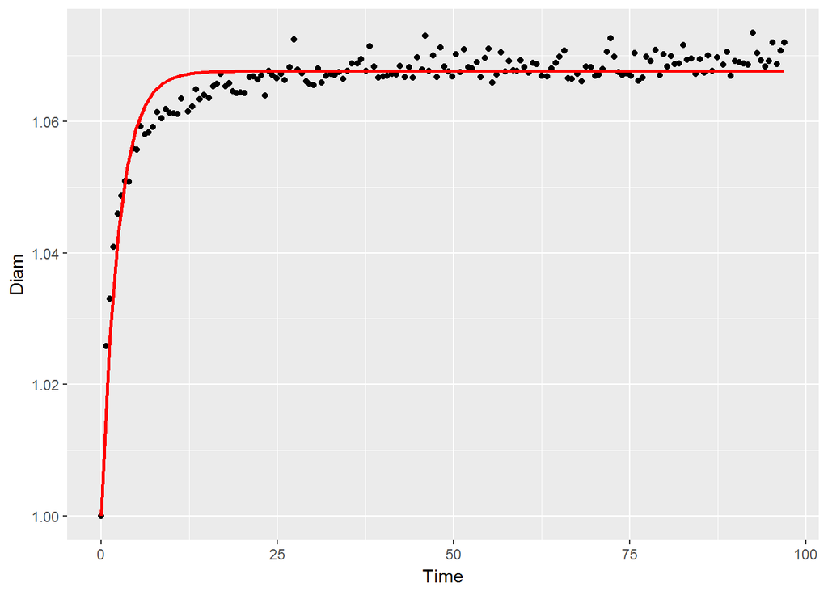

```r
#plot for Diam vs time#
Diamplot1<-ggplot(data=CAM, aes(x=Time,y=Diam))+
  geom_point()+
  geom_smooth(method="nls",
              formula=y~1+b*(1-exp(-x/a)),
              method.args=list(start=c(a=1, b=1)),
              se=FALSE,
              data=CAM,
              color="red")

print(Diamplot1)
```

```r
#Coefficient of Correlation for Diam vs Time model#
Rsquared_Diam <- cor(CAM$Diam, predict(m))

#generate table for regression parameters#
library(broom)
reg <- tidy(m)

#transform a parameter into range of regression#
a <- reg$estimate
a <- a[c(1)]
range <- 3*a

#make a variable for the b parameter for diameter vs time#
b <- reg$estimate
b <- b[c(2)]

#regression for CAO=(CA/Cao) vs Time#
m3 <- nls(CAO~1+e*(Time^f),start=list(e=1,f=1), data=CAM)
m3
```

```
## Nonlinear regression model
##   model: CAO ~ 1 + e * (Time^f)
##    data: CAM
##        e        f
## -0.04603  0.31949
##  residual sum-of-squares: 0.007597
##
## Number of iterations to convergence: 9
## Achieved convergence tolerance: 1.496e-06
```

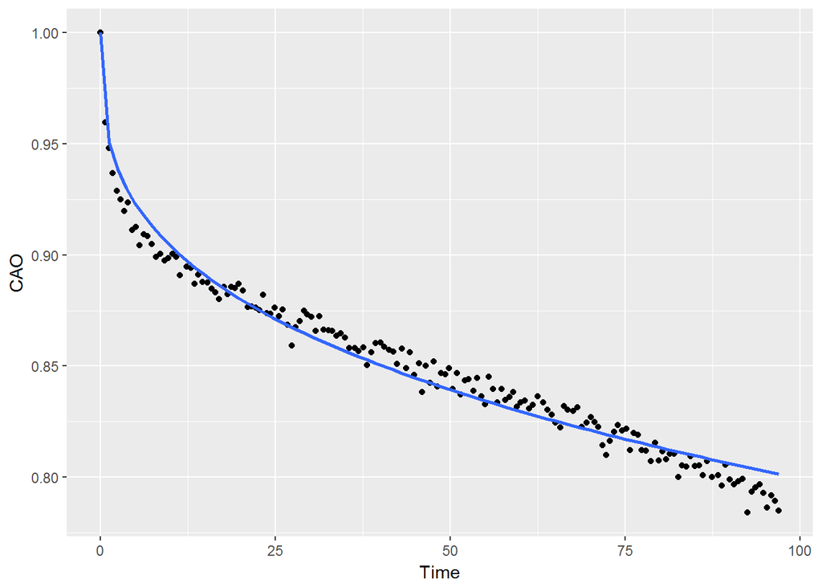

```r
#plot for m3#
CAOplot <- ggplot(data=CAM, aes(x=Time, y=CAO))+
  geom_point()+
  geom_smooth(method="nls",
              formula=y~1+(e*x^f),
              method.args=list(start=c(e=1, f=1)),
              se=FALSE)

print(CAOplot)
```

```r
#Coefficient of correlation for CA/CAo vs Time (model=m3)#
Rsquared_CAO <- cor(CAM$CAO, predict(m3))

#generate table for regression parameters#
reg3<- tidy(m3)

e <- reg3$estimate
e <- e[c(1)]

f <- reg3$estimate
f <- f[c(2)]

#regression for CA using next method#
m4 <- nls(CAT~h*(Time^g)+1,start=list(h=1,g=1), data=CAM)
m4
```

```
## Nonlinear regression model
##   model: CAT ~ h * (Time^g) + 1
##    data: CAM
##       h       g
## 0.04303 0.38266
##  residual sum-of-squares: 0.01739
##
## Number of iterations to convergence: 9
## Achieved convergence tolerance: 2.206e-06
```

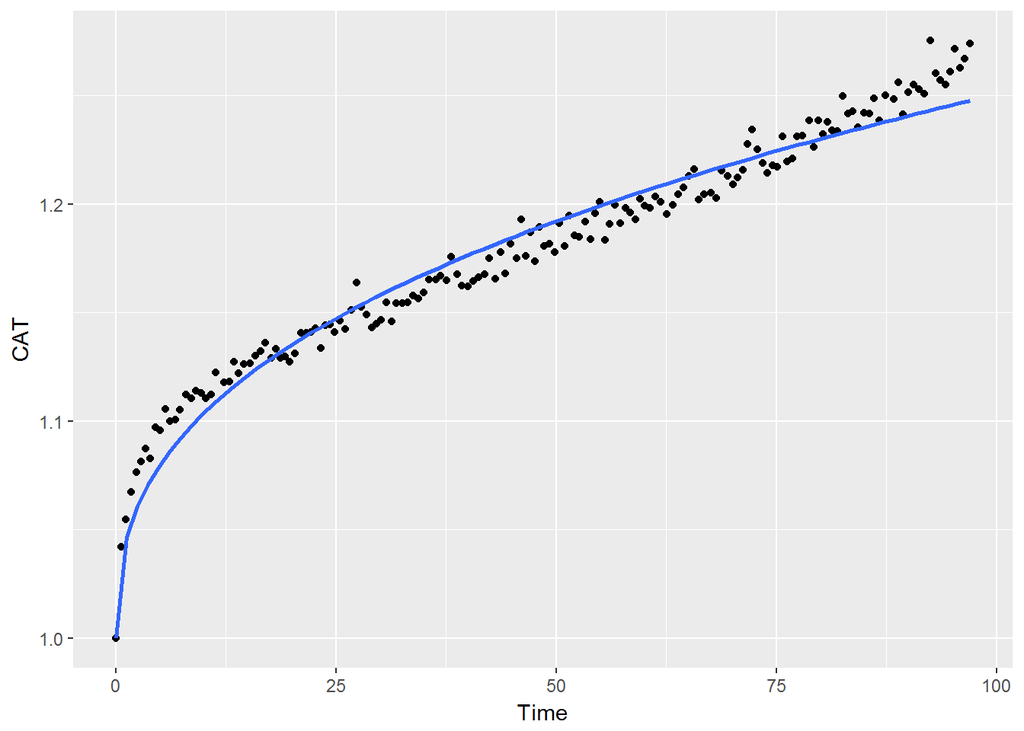

```r
CATplot <- ggplot(data=CAM, aes(x=Time, y=CAT))+
  geom_point()+
  geom_smooth(method="nls",
              formula=y~1+(h*(x^g)),
              method.args=list(start=c(h=1, g=1)),
              se=FALSE)
print(CATplot)
```

```r
Rsquared_CAT <- cor(CAM$CAT, predict(m4))

#generate table or regression parameters#
reg4 <- tidy(m4)

h <- reg4$estimate
h <- h[c(1)]

g <- reg4$estimate
g <- g[c(2)]

#Fit CAeq using the range from Diam vs Time regression and the model m4#
CATeq <- (Co)/(1+(h*(range^g)))

#Fit CAeq using the range from Diam vs Time regression and the model m3#
CAOeq <- (1+e*range^f)*(Co)

#Store the information for this rep in a data frame#
CM_S2_2C <- data.frame(range, b, e, f, g, h, Rsquared_Diam, Rsquared_CAO, Rsquared_CAT, CAOeq, CATeq)
```

## Results

The results for this analysis are shown in the table below. The R-squared values for each of the regressions, as well as all of the results and parameters for the regressions are shown in the table. These results show the mean equilibrium advancing contact angle (CAOeq) for each trial. These results are only for the Carthage Marble. The mean equilibrium advancing contact angle of all 12 of these trails was found to be 75.6 degrees.

```r
CM_Data <- rbind.data.frame(CM_S1_1A=CM_S1_1A, CM_S1_1B=CM_S1_1B, CM_S1_1C=CM_S1_1C, CM_S1_2A=CM_S1_2A, CM_S1_2B=CM_S1_2B, CM_S1_2C=CM_S1_2C, CM_S2_1A=CM_S2_1A, CM_S2_1B=CM_S2_1B, CM_S2_1C=CM_S2_1C, CM_S2_2A=CM_S2_2A, CM_S2_2B=CM_S2_2B, CM_S2_2C=CM_S2_2C)

Mean_Eq_Adv_Contact_Angle_CM <- mean(CM_Data[["CAOeq"]])

print(CM_Data, digits = NULL,
      quote = FALSE, right = TRUE, row.names = TRUE)
```

```
##              range          b           e         f         g          h
## CM_S1_1A  1.423649 0.09645755 -0.13686083 0.1443368 0.1901972 0.15109395
## CM_S1_1B  4.551046 0.08993186 -0.04516210 0.2652040 0.3024376 0.04486350
## CM_S1_1C  2.605410 0.04688790 -0.04917672 0.2395211 0.2746976 0.04911550
## CM_S1_2A  7.572744 0.10379863 -0.07104771 0.2222130 0.2668403 0.07208638
## CM_S1_2B 14.178063 0.11328953 -0.07090254 0.2281837 0.2669076 0.07387418
## CM_S1_2C 12.810958 0.12011761 -0.07548049 0.2175874 0.2575341 0.07863285
## CM_S2_1A 18.300808 0.06581704 -0.03096683 0.3728971 0.4349632 0.02814123
## CM_S2_1B 20.652897 0.08358963 -0.04490464 0.2762716 0.3120084 0.04517600
## CM_S2_1C 12.245642 0.06240471 -0.02952834 0.3382409 0.3787977 0.02842990
## CM_S2_2A  5.006723 0.10521132 -0.07888036 0.2163283 0.2621470 0.08102017
## CM_S2_2B  9.713551 0.04872776 -0.02992827 0.3363853 0.3775594 0.02876808
## CM_S2_2C  7.249562 0.06765030 -0.04603004 0.3194898 0.3826570 0.04302520
##          Rsquared_Diam Rsquared_CAO Rsquared_CAT    CAOeq    CATeq
## CM_S1_1A     0.7832933    0.9624930    0.9558977 64.92907 65.30118
## CM_S1_1B     0.9771222    0.9902362    0.9887020 75.00855 75.10943
## CM_S1_1C     0.9230583    0.9855380    0.9835392 79.87575 80.02882
## CM_S1_2A     0.9610856    0.9730818    0.9674154 77.53440 77.64834
## CM_S1_2B     0.9725896    0.9937164    0.9955598 77.40818 77.36135
## CM_S1_2C     0.9756510    0.9879207    0.9873329 76.86024 76.84166
## CM_S2_1A     0.9507864    0.9856160    0.9817973 74.42859 74.50507
## CM_S2_1B     0.9759257    0.9945523    0.9956226 77.06342 77.02499
## CM_S2_1C     0.9842352    0.9864996    0.9846251 74.54493 74.58434
## CM_S2_2A     0.9707733    0.9909738    0.9884958 77.47894 77.63328
## CM_S2_2B     0.9560681    0.9912591    0.9897313 76.86016 76.92106
## CM_S2_2C     0.9507709    0.9847820    0.9811847 75.28956 75.50227
```

```r
Mean_Eq_Adv_Contact_Angle_CM
```

```
## [1] 75.60682
```

```r
write.csv(CM_Data,"C:/Users/dell user/Desktop/GEOL_590/590_Final.csv")
```